# Circle Feature: Circle around Biel, Switzerland

## Disaggregating Precipitation

The precipitation data is aggregated from the forecast reference time (see last key in the request above: `'timespan' : 'fs'`), meaning each hourly forecast value represents the amount of precipitation from hour 0 up to the given lead time. To convert precipitation accumulated over the whole forecast time into one-hour precipitation, we use the deaccumulate() function provided by the temporal module in earthkit-transforms.

```python
import earthkit.transforms.temporal as temporal

deaccumulated_forecast = temporal.deaccumulate(
    ds, time_dim= "steps",
    accumulation_type="start_of_forecast"
    )

deaccumulated_forecast
```

```
<xarray.Dataset> Size: 17kB
Dimensions:    (datetimes: 1, number: 1, steps: 4, points: 260)
Coordinates:
  * datetimes  (datetimes) <U20 80B '2026-10-08T03:00:00Z'
  * number     (number) int64 8B 0
  * steps      (steps) int64 32B 7 8 9 10
  * points     (points) int64 2kB 0 1 2 3 4 5 6 ... 253 254 255 256 257 258 259
    latitude   (points) float64 2kB 47.05 47.06 47.06 ... 47.25 47.25 47.25
    longitude  (points) float64 2kB 7.261 7.238 7.28 7.224 ... 7.275 7.251 7.238
    levelist   (points) float64 2kB 0.0 0.0 0.0 0.0 0.0 ... 0.0 0.0 0.0 0.0 0.0
Data variables:
    tot_prec   (datetimes, number, steps, points) float64 8kB 0.582 ... 1.0
Attributes:
    class:          od
    Forecast date:  2026-10-08T03:00:00Z
    expver:         0001
    levtype:        sfc
    model:          icon-ch1-eps
    step:           6
    stream:         enfo
    timespan:       fs
    type:           cf
    number:         0
    date:           2026-10-08T03:00:00Z
```

Only 4 time steps remain, as each step now represents the accumulated precipitation between two consectuive lead times. For example step 7 encodes the expected precipitation amount between lead time 6 and 7.

## Plotting

```
<bound method Figure.show of <earthkit.plots.components.figures.Figure object at 0x7f105c84dd10>>
```

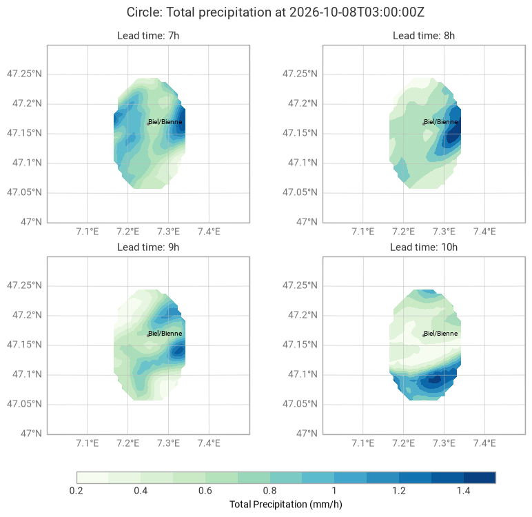

```python
from earthkit.plots import Figure
from earthkit.plots.styles import Style
from earthkit.plots.styles.levels import Levels
from earthkit.plots.geography import bounds, domains
import cartopy.crs as ccrs
import matplotlib.ticker as mticker

xmin, xmax = 7, 7.5   # Longitude bounds
ymin, ymax = 47, 47.3   # Latitude bounds

bbox = bounds.BoundingBox(xmin, xmax, ymin, ymax, ccrs.Geodetic())
domain = domains.Domain.from_bbox(bbox=bbox, name="Biel")

style = Style(
    colors="GnBu",
)

steps = deaccumulated_forecast["steps"].values

figure = Figure(rows=2, columns=2)

for step in steps:
    chart = figure.add_map(domain=domain)
    chart.contourf(deaccumulated_forecast.sel(steps=step), x="longitude", y="latitude", style=style)

    chart.coastlines()
    chart.borders()
    chart.cities("high")
    chart.gridlines()

    chart.title(f"Lead time: {int(step)}h")

figure.title("Circle: Total precipitation at {datetimes}")
figure.legend(label="Total Precipitation (mm/h)")
figure.show
```